# Comparing a Naive Model, a Logistic Regression, and a Random Forest

Author: Tim Gorman </br> In this notebook I will be running two different types of models on data curated from the kaggle pairs.csv file. The data is a subset of pairs.csv that is limited to country = 'US'. First I will run both models on data with string differences measured by cosine similarity.

```python
import pandas as pd
import numpy as np
from sklearn.model_selection import (train_test_split, cross_validate,
                                    StratifiedKFold, GridSearchCV, RandomizedSearchCV)
```

```python
from sklearn.linear_model import LogisticRegression
```

```python
from sklearn.metrics import (confusion_matrix, roc_auc_score, f1_score,
                            accuracy_score, precision_score, recall_score,
                            precision_recall_curve, roc_curve)
```

```python
import seaborn as sns
```

```python
import matplotlib.pyplot as plt
```

```python
import random
```

```python
# This data is the curated data that comes out of "data_prep2.0"
data = pd.read_csv(r"..\..\data_curated\pairs_us_diffs.csv", low_memory = False)
```

```python
data.dtypes
```

```
id_1                    object
name_1                  object
latitude_1             float64
longitude_1            float64
address_1               object
city_1                  object
state_1                 object
zip_1                   object
country_1               object
url_1                   object
phone_1                 object
categories_1            object
id_2                    object
name_2                  object
latitude_2             float64
longitude_2            float64
address_2               object
city_2                  object
state_2                 object
zip_2                   object
country_2               object
url_2                   object
phone_2                 object
categories_2            object
match                     bool
geo_diff               float64
name_diff_seq          float64
name_diff_lev          float64
address_diff_seq       float64
address_diff_lev       float64
city_diff_seq          float64
city_diff_lev          float64
state_diff_seq         float64
state_diff_lev         float64
zip_diff_seq           float64
zip_diff_lev           float64
url_diff_seq           float64
url_diff_lev           float64
phone_diff_seq         float64
phone_diff_lev         float64
categories_diff_seq    float64
categories_diff_lev    float64
geo_theta_diff         float64
name_csim              float64
address_csim           float64
city_csim              float64
state_csim             float64
zip_csim               float64
url_csim               float64
phone_csim             float64
categories_csim        float64
dtype: object
```

```python
data.columns
```

```
Index(['id_1', 'name_1', 'latitude_1', 'longitude_1', 'address_1', 'city_1',
       'state_1', 'zip_1', 'country_1', 'url_1', 'phone_1', 'categories_1',
       'id_2', 'name_2', 'latitude_2', 'longitude_2', 'address_2', 'city_2',
       'state_2', 'zip_2', 'country_2', 'url_2', 'phone_2', 'categories_2',
       'match', 'geo_diff', 'name_diff_seq', 'name_diff_lev',
       'address_diff_seq', 'address_diff_lev', 'city_diff_seq',
       'city_diff_lev', 'state_diff_seq', 'state_diff_lev', 'zip_diff_seq',
       'zip_diff_lev', 'url_diff_seq', 'url_diff_lev', 'phone_diff_seq',
       'phone_diff_lev', 'categories_diff_seq', 'categories_diff_lev',
       'geo_theta_diff', 'name_csim', 'address_csim', 'city_csim',
       'state_csim', 'zip_csim', 'url_csim', 'phone_csim', 'categories_csim'],
      dtype='object')
```

```python
feature_dict = {'x_col_csim': ['geo_theta_diff', 'name_csim', 'address_csim',
       'city_csim', 'state_csim', 'zip_csim', 'url_csim', 'phone_csim',
       'categories_csim'],
                'x_col_seq':['geo_theta_diff', 'name_diff_seq',
       'address_diff_seq', 'city_diff_seq','state_diff_seq', 'zip_diff_seq',
       'url_diff_seq', 'phone_diff_seq', 'categories_diff_seq'],
               'x_col_lev':['geo_theta_diff', 'name_diff_lev',
       'address_diff_lev', 'city_diff_lev','state_diff_lev', 'zip_diff_lev',
       'url_diff_lev', 'phone_diff_lev', 'categories_diff_lev'] }
```

```python
feature_dict['x_col_csim']
```

```
['geo_theta_diff',
 'name_csim',
 'address_csim',
 'city_csim',
 'state_csim',
 'zip_csim',
 'url_csim',
 'phone_csim',
 'categories_csim']
```

## Logistic Regression With Hyperparameter tuning and K-fold Cross_validation

```python
def logistic_regression_pipe(features, labels):
    x_train, x_test, y_train, y_test = train_test_split(features, labels,
                                                    shuffle = True,
                                                    random_state = 614,
                                                   test_size = 0.2,
                                                   stratify = labels)
    skf = StratifiedKFold(n_splits = 10, shuffle = True, random_state = 614)
    lreg = LogisticRegression()
    #HyperParameters
    solvers = ['newton-cg', 'lbfgs', 'liblinear']
    penalty = ['l2']
    c_values = [100, 50, 10, 5, 1.0, 0.5, 0.1, 0.05, 0.01]
    grid = dict(solver=solvers,penalty=penalty,C=c_values)
    grid_search = GridSearchCV(estimator=lreg, param_grid=grid, n_jobs=-1, cv=skf, scoring='accuracy',error_score=0)
    grid_result = grid_search.fit(x_train, y_train)
    print("Best: %f using %s" % (grid_result.best_score_, grid_result.best_params_))
    means = grid_result.cv_results_['mean_test_score']
    stds = grid_result.cv_results_['std_test_score']
    params = grid_result.cv_results_['params']
    for mean, stdev, param in zip(means, stds, params):
        print("%f (%f) with: %r" % (mean, stdev, param))
    return means, stds, params
```

```python
for features in feature_dict:
    print(features)
    logistic_regression_pipe(features = data[feature_dict[features]], labels = data['match'])
```

```
x_col_csim
Best: 0.739523 using {'C': 0.05, 'penalty': 'l2', 'solver': 'newton-cg'}
0.739226 (0.002530) with: {'C': 100, 'penalty': 'l2', 'solver': 'newton-cg'}
0.739215 (0.002520) with: {'C': 100, 'penalty': 'l2', 'solver': 'lbfgs'}
0.739237 (0.002512) with: {'C': 100, 'penalty': 'l2', 'solver': 'liblinear'}
0.739226 (0.002530) with: {'C': 50, 'penalty': 'l2', 'solver': 'newton-cg'}
0.739215 (0.002520) with: {'C': 50, 'penalty': 'l2', 'solver': 'lbfgs'}
0.739237 (0.002512) with: {'C': 50, 'penalty': 'l2', 'solver': 'liblinear'}
0.739237 (0.002545) with: {'C': 10, 'penalty': 'l2', 'solver': 'newton-cg'}
0.739215 (0.002530) with: {'C': 10, 'penalty': 'l2', 'solver': 'lbfgs'}
0.739247 (0.002527) with: {'C': 10, 'penalty': 'l2', 'solver': 'liblinear'}
0.739226 (0.002537) with: {'C': 5, 'penalty': 'l2', 'solver': 'newton-cg'}
0.739205 (0.002521) with: {'C': 5, 'penalty': 'l2', 'solver': 'lbfgs'}
0.739237 (0.002519) with: {'C': 5, 'penalty': 'l2', 'solver': 'liblinear'}
0.739184 (0.002523) with: {'C': 1.0, 'penalty': 'l2', 'solver': 'newton-cg'}
0.739184 (0.002523) with: {'C': 1.0, 'penalty': 'l2', 'solver': 'lbfgs'}
0.739173 (0.002507) with: {'C': 1.0, 'penalty': 'l2', 'solver': 'liblinear'}
0.739194 (0.002507) with: {'C': 0.5, 'penalty': 'l2', 'solver': 'newton-cg'}
0.739205 (0.002506) with: {'C': 0.5, 'penalty': 'l2', 'solver': 'lbfgs'}
0.739215 (0.002516) with: {'C': 0.5, 'penalty': 'l2', 'solver': 'liblinear'}
0.739364 (0.002624) with: {'C': 0.1, 'penalty': 'l2', 'solver': 'newton-cg'}
0.739343 (0.002621) with: {'C': 0.1, 'penalty': 'l2', 'solver': 'lbfgs'}
0.739353 (0.002634) with: {'C': 0.1, 'penalty': 'l2', 'solver': 'liblinear'}
0.739523 (0.002410) with: {'C': 0.05, 'penalty': 'l2', 'solver': 'newton-cg'}
0.739513 (0.002407) with: {'C': 0.05, 'penalty': 'l2', 'solver': 'lbfgs'}
0.739396 (0.002436) with: {'C': 0.05, 'penalty': 'l2', 'solver': 'liblinear'}
0.738950 (0.002206) with: {'C': 0.01, 'penalty': 'l2', 'solver': 'newton-cg'}
0.738929 (0.002209) with: {'C': 0.01, 'penalty': 'l2', 'solver': 'lbfgs'}
0.738929 (0.002230) with: {'C': 0.01, 'penalty': 'l2', 'solver': 'liblinear'}
x_col_seq
Best: 0.752044 using {'C': 0.1, 'penalty': 'l2', 'solver': 'liblinear'}
0.751928 (0.002916) with: {'C': 100, 'penalty': 'l2', 'solver': 'newton-cg'}
0.751917 (0.002918) with: {'C': 100, 'penalty': 'l2', 'solver': 'lbfgs'}
0.751928 (0.002918) with: {'C': 100, 'penalty': 'l2', 'solver': 'liblinear'}
0.751928 (0.002916) with: {'C': 50, 'penalty': 'l2', 'solver': 'newton-cg'}
0.751928 (0.002916) with: {'C': 50, 'penalty': 'l2', 'solver': 'lbfgs'}
0.751917 (0.002918) with: {'C': 50, 'penalty': 'l2', 'solver': 'liblinear'}
0.751917 (0.002918) with: {'C': 10, 'penalty': 'l2', 'solver': 'newton-cg'}
0.751917 (0.002918) with: {'C': 10, 'penalty': 'l2', 'solver': 'lbfgs'}
0.751928 (0.002916) with: {'C': 10, 'penalty': 'l2', 'solver': 'liblinear'}
```

[output cut: 32 more lines]

```
0.758544 (0.002776) with: {'C': 1.0, 'penalty': 'l2', 'solver': 'newton-cg'}
0.758554 (0.002753) with: {'C': 1.0, 'penalty': 'l2', 'solver': 'lbfgs'}
0.758576 (0.002801) with: {'C': 1.0, 'penalty': 'l2', 'solver': 'liblinear'}
0.758544 (0.002766) with: {'C': 0.5, 'penalty': 'l2', 'solver': 'newton-cg'}
0.758533 (0.002759) with: {'C': 0.5, 'penalty': 'l2', 'solver': 'lbfgs'}
0.758576 (0.002801) with: {'C': 0.5, 'penalty': 'l2', 'solver': 'liblinear'}
0.758586 (0.002703) with: {'C': 0.1, 'penalty': 'l2', 'solver': 'newton-cg'}
0.758586 (0.002703) with: {'C': 0.1, 'penalty': 'l2', 'solver': 'lbfgs'}
0.758724 (0.002730) with: {'C': 0.1, 'penalty': 'l2', 'solver': 'liblinear'}
0.758777 (0.002658) with: {'C': 0.05, 'penalty': 'l2', 'solver': 'newton-cg'}
0.758777 (0.002658) with: {'C': 0.05, 'penalty': 'l2', 'solver': 'lbfgs'}
0.759011 (0.002634) with: {'C': 0.05, 'penalty': 'l2', 'solver': 'liblinear'}
0.759914 (0.002477) with: {'C': 0.01, 'penalty': 'l2', 'solver': 'newton-cg'}
0.759914 (0.002477) with: {'C': 0.01, 'penalty': 'l2', 'solver': 'lbfgs'}
0.760583 (0.002631) with: {'C': 0.01, 'penalty': 'l2', 'solver': 'liblinear'}
```

What I get from above is that the levenshtein distance works as the best metric. I ran this twice with "geo_diff" and "geo_theta_diff" (not shown with "geo_diff"). They give nearly identical results so I'll stick with "geo_theta_diff" because I believe it to be the most accurate metric. </br> </br> Here's what I will use for the "best logistic regression" on the test set.

x_col_lev Best: 0.760583 using {'C': 0.01, 'penalty': 'l2', 'solver': 'liblinear'}

```python
lreg_best = LogisticRegression(penalty = 'l2', solver = 'liblinear', C = 0.01)
```

```python
#Defining Test Set that will be used for next logistic regression
x_train, x_test, y_train, y_test = train_test_split(data[feature_dict['x_col_lev']], data['match'],
                                                    shuffle = True,
                                                    random_state = 614,
                                                   test_size = 0.2,
                                                   stratify = data['match'])
```

```python
scores = cross_validate(lreg_best, x_train, y_train, cv = skf, scoring = ['accuracy', 'roc_auc', 'f1', 'average_precision', 'jaccard'], n_jobs = -1)
```

```python
scores
```

```
{'fit_time': array([0.36902475, 0.39507747, 0.43336391, 0.38777542, 0.37970042,
        0.40274   , 0.41911864, 0.41574788, 0.25061703, 0.23303461]),
 'score_time': array([0.04690456, 0.03272486, 0.04801846, 0.0498209 , 0.05081773,
        0.03128386, 0.03345752, 0.03345871, 0.03533673, 0.01856518]),
 'test_accuracy': array([0.75629181, 0.76330041, 0.76136364, 0.76316907, 0.76306287,
        0.75892099, 0.75849618, 0.76412489, 0.75754036, 0.7595582 ]),
 'test_roc_auc': array([0.73734311, 0.74465681, 0.74237967, 0.74404949, 0.74704447,
        0.73995227, 0.7331538 , 0.742873  , 0.73376506, 0.73876965]),
 'test_f1': array([0.84594214, 0.85061323, 0.84883956, 0.8499529 , 0.8499361 ,
        0.84779402, 0.84736206, 0.85104956, 0.84693262, 0.84776762]),
 'test_average_precision': array([0.85627348, 0.86114962, 0.85836216, 0.86138421, 0.8626865 ,
        0.86137614, 0.85574376, 0.8598007 , 0.85416546, 0.85685274]),
 'test_jaccard': array([0.73301536, 0.74005831, 0.73737728, 0.73905921, 0.73903381,
        0.73580074, 0.73515024, 0.74071912, 0.73450401, 0.73576097])}
```

Results

```python
print('Mean Accuracy')
print(np.mean(scores['test_accuracy']))
print('Mean roc_auc')
print(np.mean(scores['test_roc_auc']))
print('Mean F1')
print(np.mean(scores['test_f1']))
print('Mean Average Precision')
print(np.mean(scores['test_average_precision']))
print('Mean Jaccard')
print(np.mean(scores['test_jaccard']))
```

```
Mean Accuracy
0.760582842053666
Mean roc_auc
0.7403987339534928
Mean F1
0.8486189798741022
Mean Average Precision
0.8587794766704114
Mean Jaccard
0.7370479052953229
```

## Logistic Regression on Test Set

```python
#lreg_best = LogisticRegression()
lreg_best.fit(x_train, y_train)
y_pred = lreg_best.predict(x_test)
```

```python
confusion_matrix(y_test, y_pred)
```

```
array([[ 2075,  4544],
       [ 1141, 15781]], dtype=int64)
```

```python
roc_auc_score(y_test, y_pred)
```

```
0.623032222942199
```

```python
f1_score(y_test, y_pred)
```

```
0.8473702580073563
```

```python
accuracy_score(y_test, y_pred)
```

```
0.7585064355804766
```

```python
precision, recall, thresholds = precision_recall_curve(y_test, lreg_best.predict_proba(x_test)[:,1])
```

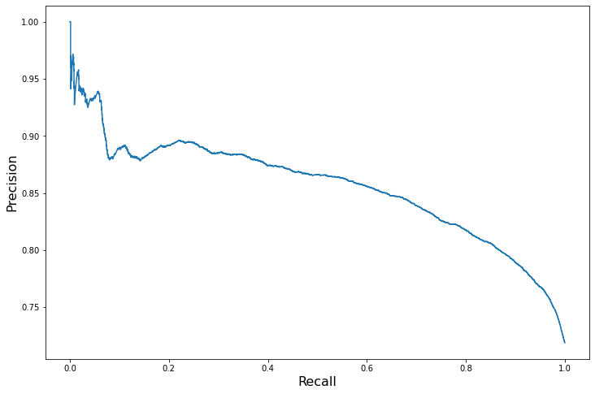

```python
plt.figure(figsize=(12,8))

plt.plot(recall,precision)

plt.xlabel("Recall",fontsize=16)
plt.ylabel("Precision",fontsize=16)

plt.show()
```

```python
fpr, tpr, thresholds = roc_curve(y_test, lreg_best.predict_proba(x_test)[:,1])
```

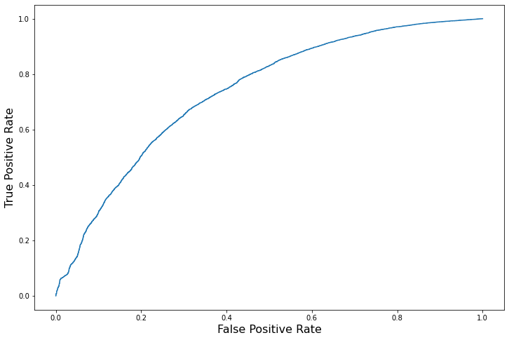

```python
plt.figure(figsize=(12,8))

plt.plot(fpr,tpr)

plt.xlabel("False Positive Rate",fontsize=16)
plt.ylabel("True Positive Rate",fontsize=16)

plt.show()
```

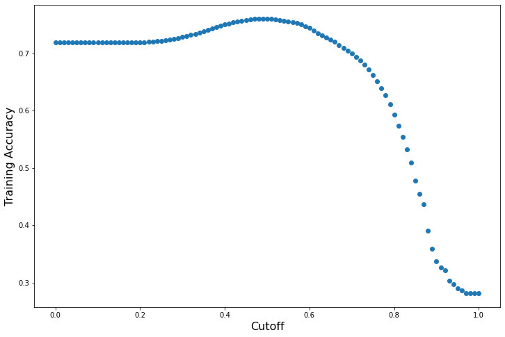

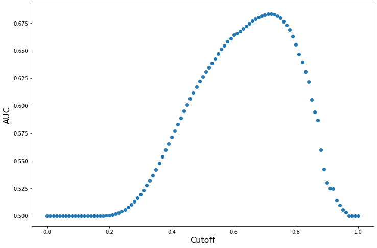

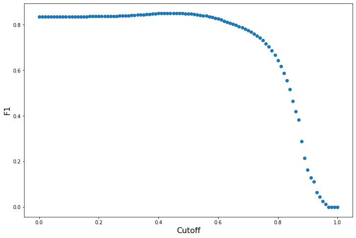

```python
cutoffs = np.arange(0, 1.01, 0.01)
y_train_prob = lreg_best.predict_proba(x_train)[:,1]
accs = []
aucs = []
f1s = []
precision = []
recall = []
for cutoff in cutoffs:
    cutoffs = np.arange(0, 1.01, 0.01)
    y_train_pred = 1*(y_train_prob >= cutoff)

    #accs.append(np.sum(y_train_pred == y_train)/len(y_train))
    accs.append(accuracy_score(y_train, y_train_pred))
    aucs.append(roc_auc_score(y_train, y_train_pred))
    f1s.append(f1_score(y_train, y_train_pred))

plt.figure(figsize=(12,8))

plt.scatter(cutoffs,accs)

plt.xlabel("Cutoff",fontsize=16)
plt.ylabel("Training Accuracy",fontsize=16)

plt.show()

plt.figure(figsize=(12,8))

plt.scatter(cutoffs,aucs)

plt.xlabel("Cutoff",fontsize=16)
plt.ylabel("AUC",fontsize=16)

plt.show()

plt.figure(figsize=(12,8))

plt.scatter(cutoffs,f1s)

plt.xlabel("Cutoff",fontsize=16)
plt.ylabel("F1",fontsize=16)

plt.show()
```

```python
max(aucs)
```

```
0.6836999400944396
```

```python
max(accs)
```

```
0.7605934453388841
```

```python
max(f1s)
```

```
0.8510941835505995
```